# Precision for Medicine - Assessment

Ishwar Pawar

10/30/2017

# Introduction

Case Study

Analyzing and studying pharmaceutical company generated gene expression data using the NanoString nCounter assay for five subjects across two-time points (i.e. 10 samples total) using R programming. Raw data from these 10 samples in NanoString’s Reporter Code Count (RCC) format have been made available along with an annotation file connecting RCC files with subjects and timepoints. Analysis Module was created to help to perform statistically-principled analyses given sample data. It brings together powerful academic open-source analysis tools via a simple interface that guides a user through the analysis to create an interactive HTML document that displays the analytical results.

Results of an analysis are displayed in two formats:

- An interactive HTML analysis report(Using R Notebook).
- R code with instructions

# Running R package “NanoStringNorm” in R studio

The workflow to operate the R studio with “NanoStringNorm” package to NanoString/RCC Analysis is very simple.

- Install and Load required libraries to read RCC files.
- Set working directory and read annotation file.
- There are two ways to import RCC files. First using read by directory and second using .xls file. As we don’t have .xls file we are going to use the first approach to read the files. That is import RCC files using read.markup.RCC function.
- display NanoString object using the head command.

# Output: Result in NanoString object.

```
## $x
##        CodeClass         Name      Accession GSM2055823_01_4353_PD_mRNA
## 1     Endogenous     TNFSF13B NM_001145645.2                        437
## 2     Endogenous         CCL5    NM_002985.2                        111
## 3     Endogenous         MCL1    NM_021960.3                       4844
## 4     Endogenous         PPBP    NM_002704.2                        214
## 5     Endogenous        CCL20    NM_004591.1                         45
## 6     Endogenous         IFNG    NM_000619.2                         74
## 7     Endogenous        CCL13    NM_005408.2                         82
## 8     Endogenous        CXCL5    NM_002994.3                        156
## 9     Endogenous        FASLG    NM_000639.1                         32
## 10    Endogenous       CXCL12    NM_199168.3                         95
## 11    Endogenous          LTB    NM_002341.1                         93
## 12    Endogenous       TXNRD1 NM_001093771.1                       2991
## 13    Endogenous       HSPA4L    NM_014278.2                        706
```

[output cut: 483 more lines]

```
## $x
##        CodeClass         Name      Accession GSM2055824_02_4355_PD_mRNA
## 1     Endogenous     TNFSF13B NM_001145645.2                        119
## 2     Endogenous         CCL5    NM_002985.2                         31
## 3     Endogenous         MCL1    NM_021960.3                       1698
## 4     Endogenous         PPBP    NM_002704.2                         45
## 5     Endogenous        CCL20    NM_004591.1                          9
## 6     Endogenous         IFNG    NM_000619.2                          8
## 7     Endogenous        CCL13    NM_005408.2                         17
## 8     Endogenous        CXCL5    NM_002994.3                         27
## 9     Endogenous        FASLG    NM_000639.1                         10
## 10    Endogenous       CXCL12    NM_199168.3                         42
## 11    Endogenous          LTB    NM_002341.1                         23
## 12    Endogenous       TXNRD1 NM_001093771.1                       1179
## 13    Endogenous       HSPA4L    NM_014278.2                        378
```

[output cut: 483 more lines]

# Normalization

In this case study, we have used 10 NanoString’s Reporter Code Count (RCC) format, that is selected baseline and post-treatment types. However, the stability of any of given gene will vary between datasets. Optimal analysis requires normalization using only the most stable subset of these genes.

The normalization module uses the popular NanoStringNorm to identify an optimal subset of genes. Its return type is either matrix or NanoStringNorm object. Following two optional parameters are used in the NanoStringNorm function.

- return.matrix.of.endogenous.probes = TRUE: To get result in matrix format.
- return.matrix.of.endogenous.probes = FALSE: To get result in NanoStringNorm

# Output after NanoString object normalization

```
##
## ##############################
## ### NanoStringNorm v1.1.21 ###
## ##############################
##
## There are 5 samples and 130 Endogenous genes
##
## Background: After correction 5 samples and 127
##  Endogenous genes have less than 90% missing.
##
## log: Setting values less than 1 to 1 in order to calculate the log in positive space.
```

```
##
## ##############################
## ### NanoStringNorm v1.1.21 ###
## ##############################
##
## There are 5 samples and 130 Endogenous genes
##
## Background: After correction 5 samples and 125
##  Endogenous genes have less than 90% missing.
##
## log: Setting values less than 1 to 1 in order to calculate the log in positive space.
```

# Output after NanoString object normalization in matrix format

```
##          GSM2055823_01_4353_PD_mRNA GSM2055825_03_3366_PD_mRNA
## TNFSF13B                      8.401                      7.687
## CCL5                          6.322                      4.248
##          GSM2055827_05_4846_PD_mRNA GSM2055829_07_3760_PD_mRNA
## TNFSF13B                      8.180                      7.322
## CCL5                          4.644                      4.000
##          GSM2055831_09_4436_PD_mRNA
## TNFSF13B                      8.224
## CCL5                          4.644
```

```
##          GSM2055824_02_4355_PD_mRNA GSM2055826_04_4078_PD_mRNA
## TNFSF13B                      7.508                      7.267
## CCL5                          5.129                      2.322
##          GSM2055828_06_3746_PD_mRNA GSM2055830_08_3790_PD_mRNA
## TNFSF13B                      9.377                      8.267
## CCL5                          3.170                      3.322
##          GSM2055832_10_4050_PD_mRNA
## TNFSF13B                      6.687
## CCL5                          4.392
```

# Problem 3.1.1 Data Processing: Normalization and Transpose

-ex: t(matrix data)

Consideration: To analyze baseline and post-treatment samples positive and negative control genes are used to assess quality by evaluating signal and noise levels. Data and heatmap is divided into baseline and post-treatment

Secondly, to generate heatmap we are going to use heatmap function. and pass the normalize nanosSting data samples in the matrix format.

# Problem 3.1.2 Output: Heatmap for basline Samples

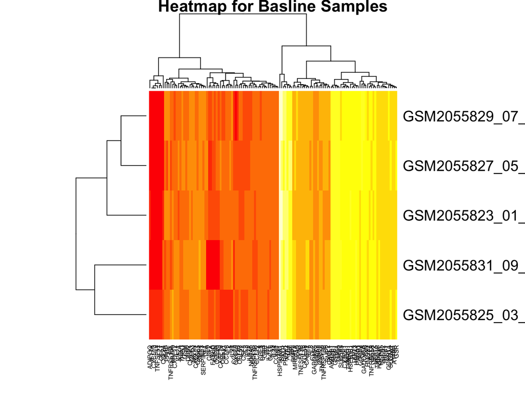

# Problem 3.1.2 Output Heatmap for Post-Treatment Samples

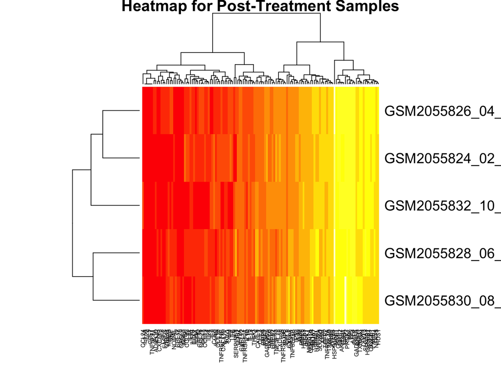

# Problem 3.2.1 Differences between the baseline and post-treatment (MCL1 and CXCL1)

To showing differences between the baseline and post-treatment timepoints for two MCL1 and CXCL1 using boxplots of summary statistics we need to subset CXCL1 and MCL1 values from Baseline/Post-Treatment sample and stored into a seperate data frame.

After subsetting the data form annotation and nanoSting normalized matrix. we combine the data using rbind () function to get the data in an appropriate format to generate boxplot using ggplot2 package.

# Problem 3.2.2 Output: Subset and combine data using r bind function.

```
##                            sample     time_point CXCL1  MCL1
## GSM2055823_01_4353_PD_mRNA      1       Baseline 7.524 11.90
## GSM2055825_03_3366_PD_mRNA      2       Baseline 7.651 12.00
## GSM2055827_05_4846_PD_mRNA      3       Baseline 6.943 11.63
## GSM2055829_07_3760_PD_mRNA      4       Baseline 8.205 11.73
## GSM2055831_09_4436_PD_mRNA      5       Baseline 7.248 11.91
## GSM2055824_02_4355_PD_mRNA      1 Post-Treatment 6.209 11.46
## GSM2055826_04_4078_PD_mRNA      2 Post-Treatment 5.728 11.49
## GSM2055828_06_3746_PD_mRNA      3 Post-Treatment 9.433 12.92
## GSM2055830_08_3790_PD_mRNA      4 Post-Treatment 5.858 12.29
## GSM2055832_10_4050_PD_mRNA      5 Post-Treatment 6.190 11.14
```